# Data analysis workflow for: Correlated evolution of body size and ommatidia size in tiger moths (Lepidoptera: Arctiidae)

Author

Félix P. Leiva

Published

13th Jul 2026

This supplementary file contains the *R* code for processing and analysing the raw data, and creating figures for the manuscript *Correlated evolution of body size and ommatidia size in tiger moths (Lepidoptera: Arctiidae)*. The manuscript is authored by **Michał Rajda**, **Łukasz Przybyłowicz**, **Félix P. Leiva** and **Marcin Czarnoleski**.

# Licence

This repository is provided by the authors under the [Attribution-NonCommercial-NoDerivatives 4.0 International licence](https://creativecommons.org/licenses/by-nc-nd/4.0/)

# Citation

When using the data and/or code associated with this repository, they must be cited as follows:

Rajda M, Przybyłowicz Ł, Leiva FP, Czarnoleski M. (2026). Correlated evolution of body size and ommatidia size in tiger moths (Lepidoptera: Arctiidae). Zenodo. pending DOI.

# Load and clean data

```r
# load data and tidy columns and levels in the dataframe
dat <- read_xlsx("../data/Moths_cell_size_data_26_01_2026.xlsx", sheet = "Data") %>%
  rename(
    ommatidia_area     = OmArea,
    forewing_lenght    = For,
    hindwing_lenght    = Hind,
    specimen_id = ID,
    species = Species,
    sex = Sex
  )
```

## Create new columns and recode when is needed

```r
dat <- dat %>%
  mutate(
    log10_ommatidia_area = log10(ommatidia_area),
    log10_forewing_lenght = log10(forewing_lenght),
    log10_hindwing_lenght = if_else(
      is.na(hindwing_lenght),
      NA_real_,
      log10(hindwing_lenght)
    ),
   # We used the forewing–hindwing ratio as a proxy for flight style: values
   # greater than 1 indicate a more active, maneuverable flight (as in
   # hawk moths), whereas values closer to 1 indicate a more gliding flight
   # style. These two flight modes reflect differences in the capacity for
   # sharp turning versus sustained long-distance flight.
    forewing_hindwing_ratio = if_else(
      is.na(hindwing_lenght),
      NA_real_,
      forewing_lenght / hindwing_lenght
    ), # calculate ratio between forewing and hindwing, explicitaly considering NAs
    species = gsub(" ", "_", species), # add underscore (_) between Genus and species (Genus_species)
    species = gsub("\\.", "", species), # Remove dots from species
    phylo = species,
    sex = recode(sex, "M" = "male", "F" = "female"), # Replace M/F by male/female
    Lifestyle = recode(Lifestyle, "Diurnal"= "diurnal", "Nocturnal"= "nocturnal")
  )
```

## Select only columns of interest and apply standard steps

```r
dat <- dat %>%
  select(-ForHind) %>% #  exclude these three columns, not useful at all
  rename_with(tolower) %>%
  rename_with(~ str_replace_all(., "\\s+", "_"))  # Replace double spaces by underscores in column names
```

## Check data structure and transform variables if necessary

```r
glimpse(dat)
```

```
Rows: 190
Columns: 14
$ lifestyle               <chr> "diurnal", "diurnal", "diurnal", "diurnal", "d…
$ origin                  <chr> "Poland", "Poland", "Poland", "Poland", "Polan…
$ tribe                   <chr> "Syntomini", "Syntomini", "Syntomini", "Syntom…
$ species                 <chr> "Amata_phegea", "Amata_phegea", "Amata_phegea"…
$ specimen_id             <dbl> 1, 2, 3, 4, 5, 6, 7, 8, 9, 10, 11, 12, 13, 14,…
$ sex                     <chr> "female", "female", "female", "male", "male", …
$ forewing_lenght         <dbl> 17, 18, 17, 17, 19, 20, 16, 15, 14, 15, 15, 15…
$ hindwing_lenght         <dbl> 8.4, 8.3, 8.0, 8.5, 9.7, 10.1, 13.2, 12.9, 12.…
$ ommatidia_area          <dbl> 453, 494, 490, 641, 594, 627, 359, 345, 350, 3…
$ log10_ommatidia_area    <dbl> 2.7, 2.7, 2.7, 2.8, 2.8, 2.8, 2.6, 2.5, 2.5, 2…
$ log10_forewing_lenght   <dbl> 1.2, 1.3, 1.2, 1.2, 1.3, 1.3, 1.2, 1.2, 1.2, 1…
$ log10_hindwing_lenght   <dbl> 0.92, 0.92, 0.90, 0.93, 0.99, 1.00, 1.12, 1.11…
$ forewing_hindwing_ratio <dbl> 2.1, 2.2, 2.2, 2.0, 2.0, 1.9, 1.2, 1.2, 1.2, 1…
$ phylo                   <chr> "Amata_phegea", "Amata_phegea", "Amata_phegea"…
```

## Variables to convert to factor

```r
columns_to_factor <- c(
  "lifestyle",
  "origin",
  "tribe",
  "species",
  "specimen_id",
  "sex",
  "phylo"
)
```

## Variables to convert to numeric

```r
columns_to_numeric <- c(
"forewing_lenght",
"hindwing_lenght",
"ommatidia_area",
"log10_ommatidia_area",
"log10_forewing_lenght",
"log10_hindwing_lenght",
"forewing_hindwing_ratio"
)
```

## Apply transformation

```r
# Apply the conversions to the dataset.
dat <- dat %>%
  mutate(
    across(all_of(columns_to_factor), as.factor),
    across(all_of(columns_to_numeric), as.numeric)
  )

# Confirm that changes have been applied correctly
glimpse(dat)
```

```
Rows: 190
Columns: 14
$ lifestyle               <fct> diurnal, diurnal, diurnal, diurnal, diurnal, d…
$ origin                  <fct> Poland, Poland, Poland, Poland, Poland, Poland…
$ tribe                   <fct> Syntomini, Syntomini, Syntomini, Syntomini, Sy…
$ species                 <fct> Amata_phegea, Amata_phegea, Amata_phegea, Amat…
$ specimen_id             <fct> 1, 2, 3, 4, 5, 6, 7, 8, 9, 10, 11, 12, 13, 14,…
$ sex                     <fct> female, female, female, male, male, male, fema…
$ forewing_lenght         <dbl> 17, 18, 17, 17, 19, 20, 16, 15, 14, 15, 15, 15…
$ hindwing_lenght         <dbl> 8.4, 8.3, 8.0, 8.5, 9.7, 10.1, 13.2, 12.9, 12.…
$ ommatidia_area          <dbl> 453, 494, 490, 641, 594, 627, 359, 345, 350, 3…
$ log10_ommatidia_area    <dbl> 2.7, 2.7, 2.7, 2.8, 2.8, 2.8, 2.6, 2.5, 2.5, 2…
$ log10_forewing_lenght   <dbl> 1.2, 1.3, 1.2, 1.2, 1.3, 1.3, 1.2, 1.2, 1.2, 1…
$ log10_hindwing_lenght   <dbl> 0.92, 0.92, 0.90, 0.93, 0.99, 1.00, 1.12, 1.11…
$ forewing_hindwing_ratio <dbl> 2.1, 2.2, 2.2, 2.0, 2.0, 1.9, 1.2, 1.2, 1.2, 1…
$ phylo                   <fct> Amata_phegea, Amata_phegea, Amata_phegea, Amat…
```

## Calculate mean per species and sex

```r
dat_mean <- dat %>%
  group_by(species, sex) %>%
  summarise(across(c(ommatidia_area, forewing_lenght, hindwing_lenght, forewing_hindwing_ratio),
                   \(x) mean(x, na.rm = TRUE)),
            .groups = "drop") %>%
  mutate(across(c(ommatidia_area, forewing_lenght, hindwing_lenght),
                ~ log10(.), .names = "log10_{col}")) %>%
  left_join(distinct(dat, lifestyle, origin, tribe, species, sex, phylo), by = c("species", "sex")) %>%
  select(lifestyle, origin, tribe, species, sex, phylo, everything())
```

# Phylogeny

What we will see next is the phylogenetic tree constructed by **Łukasz Przybyłowicz**, one of the co-authors of the manuscript, which includes 31 moth species.

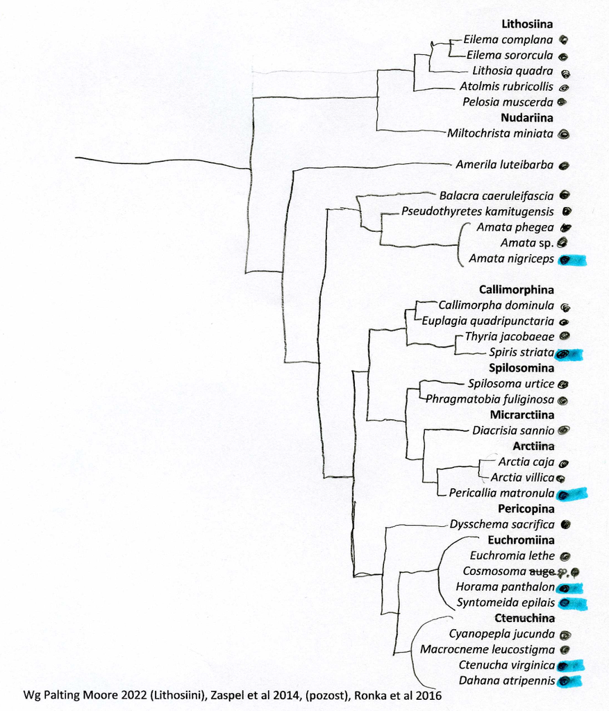

Because we aim to account for the evolutionary history of these species, we need to generate a phylogenetic tree in a format such as `.tree` or `.nwk`. This will later allow us to import it into R to calculate the variance–covariance matrix and the corresponding correlation needed for the statistical models.

The following code first defines a Newick-formatted string (species_moths) representing the evolutionary relationships among 31 species, as shown in the previous Figure. This string is read using the read.tree() function (from the ape package) and a *phylo* object, which can be plotted to display the same relationships as in the previous figure. The tree is also exported and saved in the output folder.

## Generate topology

Here, what I do is simply copy and paste the species names and use parentheses. For more details about the Newick formatting, I suggest to check at [The Newick tree format](https://phylipweb.github.io/phylip/newicktree.html).

```r
species_moths <-
"((((((Eilema_complana,Eilema_sororcula),Lithosia_quadra),Atolmis_rubricollis),Pelosia_muscerda),Miltochrista_miniata),(Amerila_luteibarba,
((Balacra_caeruleifascia,(Pseudothyretes_kamitugensis,
(Amata_phegea,Amata_sp,Amata_nigriceps))),
((((Callimorpha_dominula,Euplagia_quadripunctaria),(Thyria_jacobaeae,Spiris_striata)),
((Spilosoma_urticae,Phragmatobia_fuliginosa),(Diacrisia_sannio,
(Pericallia_matronula,(Arctia_caja,Arctia_villica))))),
(Dysschema_sacrifica,
((Euchromia_lethe,Cosmosoma_sp,Horama_panthalon,Syntomeida_epilais),
((Cyanopepla_jucunda,Macrocneme_leucostigma,Ctenucha_virginica,Dahana_atripennis)
 )))))));"

# Read tree from Newick string
tree_moths <- read.tree(text = species_moths)

# Get tip labels (species)
tree_moths$tip.label
```

```
 [1] "Eilema_complana"             "Eilema_sororcula"
 [3] "Lithosia_quadra"             "Atolmis_rubricollis"
 [5] "Pelosia_muscerda"            "Miltochrista_miniata"
 [7] "Amerila_luteibarba"          "Balacra_caeruleifascia"
 [9] "Pseudothyretes_kamitugensis" "Amata_phegea"
[11] "Amata_sp"                    "Amata_nigriceps"
[13] "Callimorpha_dominula"        "Euplagia_quadripunctaria"
[15] "Thyria_jacobaeae"            "Spiris_striata"
[17] "Spilosoma_urticae"           "Phragmatobia_fuliginosa"
[19] "Diacrisia_sannio"            "Pericallia_matronula"
[21] "Arctia_caja"                 "Arctia_villica"
[23] "Dysschema_sacrifica"         "Euchromia_lethe"
[25] "Cosmosoma_sp"                "Horama_panthalon"
[27] "Syntomeida_epilais"          "Cyanopepla_jucunda"
[29] "Macrocneme_leucostigma"      "Ctenucha_virginica"
[31] "Dahana_atripennis"
```

## Plot the tree

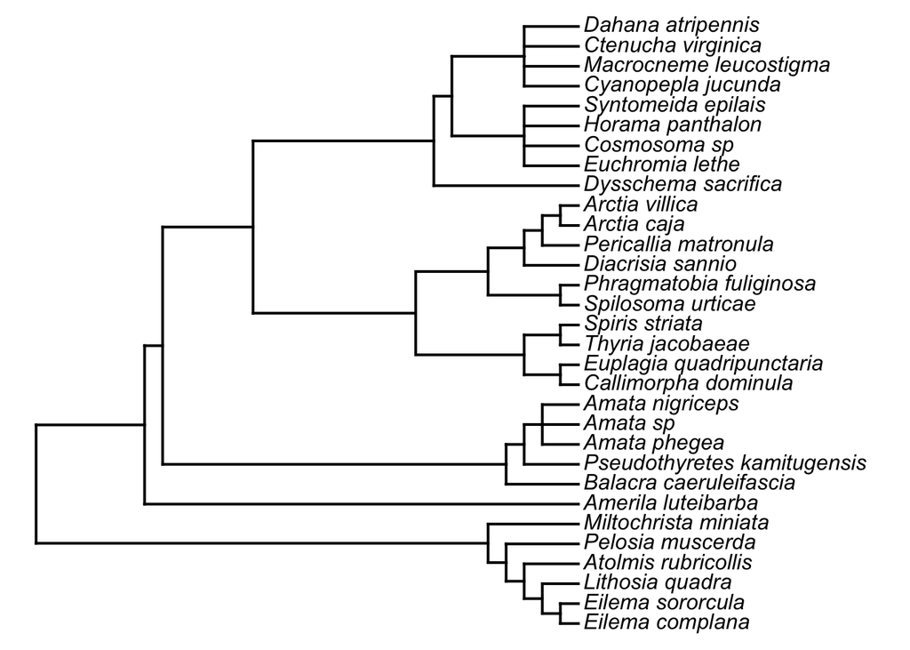

```r
plotTree(tree_moths, ftype = "i", lwd = 2)
```

## Export the tree

```r
write.tree(tree_moths, "../outputs/tree_moths_updated.tre")
```

## Merge phylogeny and data

The next step is to check whether all the species in our dataframe are included in the tree and vice versa. To do this, we will compare the species names listed in the “phylo” column with the tip labels of the tree.

```r
setdiff(tree_moths$tip.label, dat_mean$phylo)      # Tree species absent in database
```

```
[1] "Spilosoma_urticae" "Diacrisia_sannio"
```

```r
setdiff(dat_mean$phylo, tree_moths$tip.label)      # Database species absent in tree
```

```
[1] "Diacrisia_sanio"  "Spilosoma_urtice"
```

```r
# Correct the misspelled species names in the dataframe column
dat_mean$species <- gsub("Diacrisia_sanio", "Diacrisia_sannio", dat_mean$species)
dat_mean$species <- gsub("Spilosoma_urtice", "Spilosoma_urticae", dat_mean$species)

dat_mean$phylo <- gsub("Diacrisia_sanio", "Diacrisia_sannio", dat_mean$phylo)
dat_mean$phylo <- gsub("Spilosoma_urtice", "Spilosoma_urticae", dat_mean$phylo)
```

```r
# Re-check for mismatches after pruning
setdiff(tree_moths$tip.label, dat_mean$phylo)
```

```
character(0)
```

```r
setdiff(dat_mean$phylo, tree_moths$tip.label)
```

```
character(0)
```

**Perfect!!!** Now all species in the dataframe are included in the tree and viceversa

## Compute branch length using Grafen

```r
tree <- compute.brlen(tree_moths, method = "Grafen")
```

## Compute of phylogenetic correlation matrix

Ojo acá! Note that the vignette by [Paul Bürkner](https://cran.r-project.org/web/packages/brms/vignettes/brms_phylogenetics.html#introductio) does not specify the argument *corr = TRUE*. For the purposes of our analysis, however, it is necessary to include this argument in order to compute the correlation between species, given their evolutionary history as represented by the phylogeny.

This allows us to see that the values range from 0 to 1. Values close to 1 indicate a high correlation between species, meaning that species are expected to share similar values for the trait of interest.

```r
A <- ape::vcv.phylo(tree, corr = TRUE)


rownames(A) <- colnames(A) <- levels(dat$phylo)
A <- A[levels(dat$phylo), levels(dat$phylo)]
```

# Figure 1

## Prepare data

```r
dat_for_figure_1 <- dat_mean %>%
  select(1:3,6)

species_counts <- dat_for_figure_1 %>%
  group_by(phylo) %>%
  summarise(n_unique_combinations = n_distinct(lifestyle, origin, tribe), .groups = "drop")

species_single_attributes <- species_counts %>%
  filter(n_unique_combinations == 1) %>%
  pull(phylo)

dat_for_figure_1 <- dat_for_figure_1 %>%
  filter(phylo %in% species_single_attributes) %>%
  distinct(phylo, .keep_all = TRUE)

summary_data <- dat_for_figure_1 %>%
  filter(phylo %in% tree_moths$tip.label)
```

## Create matrices with rownames matching tree tip labels

```r
dat_moths_lifestyle <- summary_data %>%
  column_to_rownames("phylo") %>%
  select(lifestyle) %>%
  as.matrix() %>%
  .[tree_moths$tip.label, , drop = FALSE]

dat_moths_origin <- summary_data %>%
  column_to_rownames("phylo") %>%
  select(origin) %>%
  as.matrix() %>%
  .[tree_moths$tip.label, , drop = FALSE]

dat_moths_tribe <- summary_data %>%
  column_to_rownames("phylo") %>%
  select(tribe) %>%
  as.matrix() %>%
  .[tree_moths$tip.label, , drop = FALSE]
```

## Make Figure

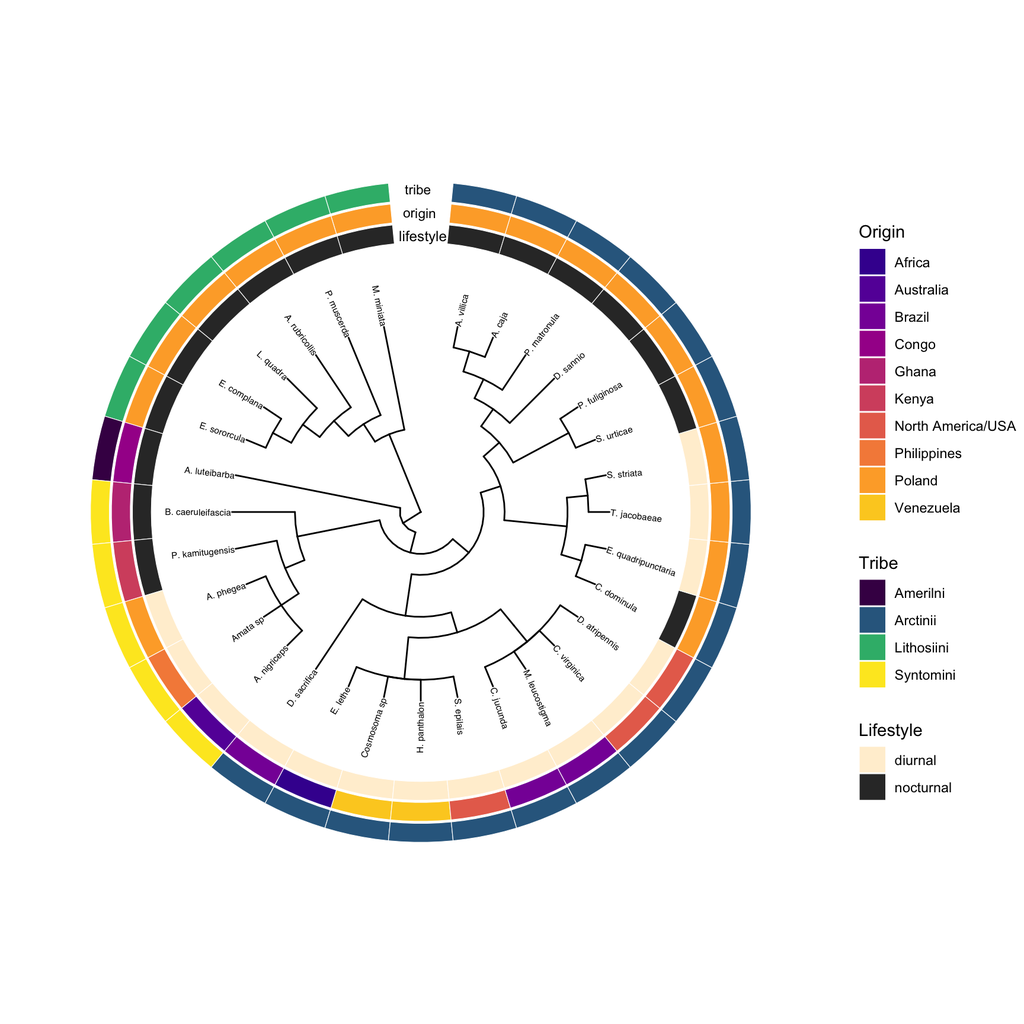

```r
## Function to abbreviate species names (Genus_species  is then G. species)

format_species <- function(x) {

  parts <- strsplit(x, "_")[[1]]

  # If no second term, return unchanged
  if (length(parts) < 2) {
    return(x)
  }

  genus   <- parts[1]
  species <- parts[2]

  # sp, sp1, sp. while keep genus and remove underscore
  if (grepl("^sp", species, ignore.case = TRUE)) {
    return(paste(genus, species))
  }

  # Valid species... abbreviate genus
  paste0(substr(genus, 1, 1), ". ", species)
}


# Colores lifestyle
lifestyle_colours <- c(
  "diurnal"   = "#FFEFD5",
  "nocturnal" = "gray20"
)

## Base tree. Circular (personal prefercne)
circ <- ggtree(tree_moths, layout = "fan", open.angle = 8) %>%
  rotate_tree(90) +
  geom_tiplab2(
    aes(label = vapply(label, format_species, character(1))),
    size = 2,
    align = TRUE,
    offset = 0
  )

# Heatmap Lifestyle
p1 <- gheatmap(
  circ,
  dat_moths_lifestyle,
  width = 0.1,
  offset = 3.4,
  colnames_angle = 0,
  colnames_offset_x = -0.1,
  colnames_offset_y = 0.4,
  hjust = 0,
  font.size = 3.2
) +
  scale_fill_manual(
    values = lifestyle_colours,
    name = "Lifestyle"
  )

# Heatmap Origin
p2 <- p1 + new_scale_fill()

p2 <- gheatmap(
  p2,
  dat_moths_origin,
  width = 0.1,
  offset = 4.4,
  colnames_angle = -0.2,
  colnames_offset_x = 0,
  colnames_offset_y = 0.3,
  hjust = 0,
  font.size = 3
) +
  # I just wanted to changed the end color
  scale_fill_viridis_d(
  option = "plasma",
  begin = 0.1,
  end = 0.9,
  name = "Origin"
)

# Heatmap 3: Tribe
p3 <- p2 + new_scale_fill()

Figure_1 <- gheatmap(
  p3,
  dat_moths_tribe,
  width = 0.1,
  offset = 5.4,
  colnames_angle = 0,
  colnames_offset_x = 0.1,
  colnames_offset_y = 0.25,
  hjust = 0,
  font.size = 3
  ) +
  scale_fill_viridis_d(option = "D", name = "Tribe") +
  theme(
    legend.position = "right",
    legend.justification = "left",
    legend.margin = margin(5, 5, 5, 5),
    plot.margin = margin(0, 0, 0, 5)
  )

Figure_1
```

```r
# Export figure
ggsave(
  "../outputs/Figure_1.pdf",
  Figure_1,
  width = 9,
  height = 9,
  units = "in"
)
```

# Does larger-bodied moths evolved larger ommatidia?

## Only body size

```r
fit_1 <- brm(
  log10_ommatidia_area ~ log10_forewing_lenght +
    (1 | gr(phylo, cov = A)) +   # phylogeny
    (1 | species),               # species-specific effects (beyond phylogeny)
  data = dat,
  family = gaussian(),
  data2 = list(A = A),
  prior = c(
    prior(normal(0,10), "b"),
    prior(normal(0,50), "Intercept"),
    prior(student_t(3,0,20), "sd"),
    prior(student_t(3,0,20), "sigma")
  ),
  seed = 6955,
  sample_prior = TRUE,
  chains = 4,
  cores = 4,
  threads = threading(2),
  iter = 4000,
  warmup = 2000,
  control = list(max_treedepth = 15,
                 adapt_delta = 0.95),
  save_pars = save_pars(all = TRUE),
  silent = TRUE, refresh = 0
)
```

## Additive effect of sex

```r
fit_2 <- brm(
  log10_ommatidia_area ~ log10_forewing_lenght +
    sex +
    (1 | gr(phylo, cov = A)) +
    (1 | species),
  data = dat,
  family = gaussian(),
  data2 = list(A = A),
  prior = c(
    prior(normal(0,10), "b"),
    prior(normal(0,50), "Intercept"),
    prior(student_t(3,0,20), "sd"),
    prior(student_t(3,0,20), "sigma")
  ),
  seed = 6955,
  sample_prior = TRUE,
  chains = 4,
  cores = 4,
  threads = threading(2),
  iter = 4000,
  warmup = 2000,
  control = list(max_treedepth = 15,
                 adapt_delta = 0.95),
  save_pars = save_pars(all = TRUE),
  silent = TRUE, refresh = 0
)
```

## Interactive effect of sex

```r
fit_3 <- brm(
  log10_ommatidia_area ~ log10_forewing_lenght *
    sex +
    (1 | gr(phylo, cov = A)) +
    (1 | species),
  data = dat,
  family = gaussian(),
  data2 = list(A = A),
  prior = c(
    prior(normal(0,10), "b"),
    prior(normal(0,50), "Intercept"),
    prior(student_t(3,0,20), "sd"),
    prior(student_t(3,0,20), "sigma")
  ),
  seed = 6955,
  sample_prior = TRUE,
  chains = 4,
  cores = 4,
  threads = threading(2),
  iter = 4000,
  warmup = 2000,
  control = list(max_treedepth = 15,
                 adapt_delta = 0.95),
  save_pars = save_pars(all = TRUE),
  silent = TRUE, refresh = 0
)
```

```
Running MCMC with 4 parallel chains, with 2 thread(s) per chain...

Chain 3 finished in 9.7 seconds.
Chain 1 finished in 10.1 seconds.
Chain 4 finished in 10.8 seconds.
Chain 2 finished in 11.1 seconds.

All 4 chains finished successfully.
Mean chain execution time: 10.4 seconds.
Total execution time: 11.2 seconds.
```

## Best model

```r
model_1 = add_criterion(fit_1, 'loo')
model_2 = add_criterion(fit_2, 'loo')
model_3 = add_criterion(fit_3, 'loo')
loo_compare(model_1,model_2,model_3)
```

```
        elpd_diff se_diff
model_3   0.0       0.0
model_2  -4.0       3.1
model_1 -54.1       7.3
```

**Model check**

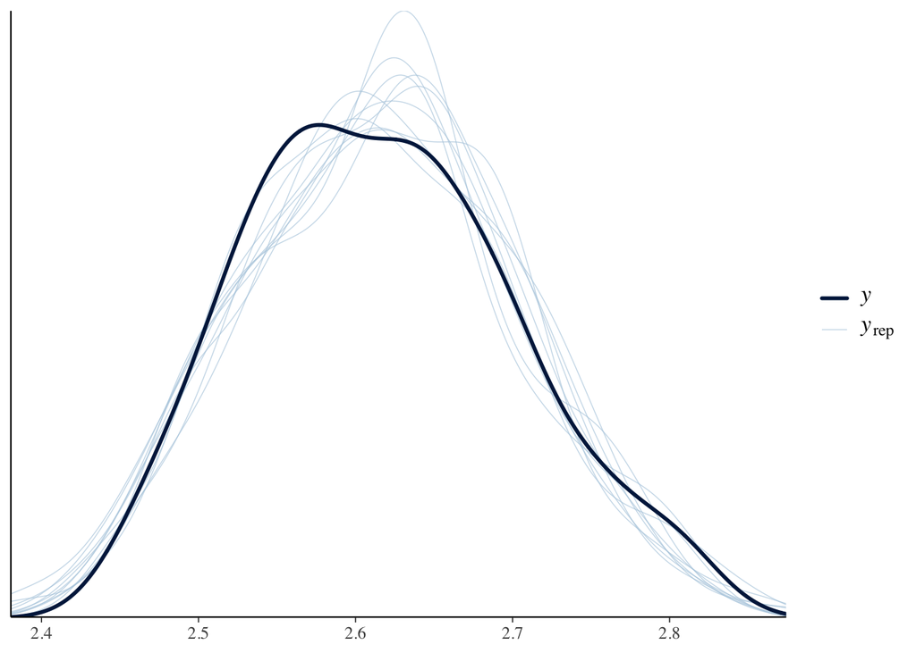

```r
pp_check(fit_3)
```

**Model summary**

```r
summary(fit_3)
```

```
 Family: gaussian
  Links: mu = identity
Formula: log10_ommatidia_area ~ log10_forewing_lenght * sex + (1 | gr(phylo, cov = A)) + (1 | species)
   Data: dat (Number of observations: 190)
  Draws: 4 chains, each with iter = 4000; warmup = 2000; thin = 1;
         total post-warmup draws = 8000

Multilevel Hyperparameters:
~phylo (Number of levels: 31)
              Estimate Est.Error l-95% CI u-95% CI Rhat Bulk_ESS Tail_ESS
sd(Intercept)     0.03      0.02     0.00     0.09 1.00      980     1740

~species (Number of levels: 31)
              Estimate Est.Error l-95% CI u-95% CI Rhat Bulk_ESS Tail_ESS
sd(Intercept)     0.05      0.01     0.04     0.07 1.00     2780     4703

Regression Coefficients:
                              Estimate Est.Error l-95% CI u-95% CI Rhat
Intercept                         2.28      0.08     2.13     2.44 1.00
log10_forewing_lenght             0.25      0.06     0.13     0.36 1.00
sexmale                          -0.10      0.05    -0.19    -0.00 1.00
log10_forewing_lenght:sexmale     0.12      0.04     0.04     0.19 1.00
                              Bulk_ESS Tail_ESS
Intercept                         4473     5322
log10_forewing_lenght             4625     5450
sexmale                           7253     5601
log10_forewing_lenght:sexmale     7263     5869

Further Distributional Parameters:
      Estimate Est.Error l-95% CI u-95% CI Rhat Bulk_ESS Tail_ESS
sigma     0.03      0.00     0.03     0.03 1.00     9336     5601

Draws were sampled using sample(hmc). For each parameter, Bulk_ESS
and Tail_ESS are effective sample size measures, and Rhat is the potential
scale reduction factor on split chains (at convergence, Rhat = 1).
```

**Bayesian p-values**

```r
p_map(fit_3)
```

```
MAP-based p-value

Parameter                     | p (MAP)
---------------------------------------
(Intercept)                   |  < .001
log10_forewing_lenght         |  < .001
sexmale                       |  0.150
log10_forewing_lenght:sexmale |  0.010
```

**Bayesian R-square**

```r
bayes_R2(fit_3)
```

```
   Estimate Est.Error Q2.5 Q97.5
R2     0.88    0.0084 0.86  0.89
```

**Phylogenetic signal**

```r
hyp <- paste(
  "sd_phylo__Intercept^2 /",
  "(sd_phylo__Intercept^2 + sd_species__Intercept^2 + sigma^2) = 0"
)
hypothesis(fit_3, hyp, class = NULL)
```

```
Hypothesis Tests for class :
                Hypothesis Estimate Est.Error CI.Lower CI.Upper Evid.Ratio
1 (sd_phylo__Interc... = 0     0.25      0.19        0     0.69       0.79
  Post.Prob Star
1      0.44    *
---
'CI': 90%-CI for one-sided and 95%-CI for two-sided hypotheses.
'*': For one-sided hypotheses, the posterior probability exceeds 95%;
for two-sided hypotheses, the value tested against lies outside the 95%-CI.
Posterior probabilities of point hypotheses assume equal prior probabilities.
```

# How does lifestyle affect whether larger-bodied moths evolved larger ommatidia?

## Additive effect of lifestyle

```r
fit_4 <- brm(
  log10_ommatidia_area ~ log10_forewing_lenght +
    lifestyle +
    (1 | gr(phylo, cov = A)) +
    (1 | species),
  data = dat,
  family = gaussian(),
  data2 = list(A = A),
  prior = c(
    prior(normal(0,10), "b"),
    prior(normal(0,50), "Intercept"),
    prior(student_t(3,0,20), "sd"),
    prior(student_t(3,0,20), "sigma")
  ),
  seed = 6955,
  sample_prior = TRUE,
  chains = 4,
  cores = 4,
  threads = threading(2),
  iter = 4000,
  warmup = 2000,
  control = list(max_treedepth = 15,
                 adapt_delta = 0.95),
  save_pars = save_pars(all = TRUE),
  silent = TRUE, refresh = 0
)
```

## Interactive effect of lifestyle

```r
fit_5 <- brm(
  log10_ommatidia_area ~ log10_forewing_lenght *
    lifestyle +
    (1 | gr(phylo, cov = A)) +
    (1 | species),
  data = dat,
  family = gaussian(),
  data2 = list(A = A),
  prior = c(
    prior(normal(0,10), "b"),
    prior(normal(0,50), "Intercept"),
    prior(student_t(3,0,20), "sd"),
    prior(student_t(3,0,20), "sigma")
  ),
  seed = 6955,
  sample_prior = TRUE,
  chains = 4,
  cores = 4,
  threads = threading(2),
  iter = 4000,
  warmup = 2000,
  control = list(max_treedepth = 15,
                 adapt_delta = 0.95),
  save_pars = save_pars(all = TRUE),
  silent = TRUE, refresh = 0
)
```

## Additive effect of lifestyle plus sex

```r
fit_6 <- brm(
  log10_ommatidia_area ~ log10_forewing_lenght +
    lifestyle +
    sex +
    (1 | gr(phylo, cov = A)) +
    (1 | species),
  data = dat,
  family = gaussian(),
  data2 = list(A = A),
  prior = c(
    prior(normal(0,10), "b"),
    prior(normal(0,50), "Intercept"),
    prior(student_t(3,0,20), "sd"),
    prior(student_t(3,0,20), "sigma")
  ),
  seed = 6955,
  sample_prior = TRUE,
  chains = 4,
  cores = 4,
  threads = threading(2),
  iter = 4000,
  warmup = 2000,
  control = list(max_treedepth = 15,
                 adapt_delta = 0.95),
  save_pars = save_pars(all = TRUE),
  silent = TRUE, refresh = 0
)
```

## Interactive effect of lifestyle plus sex

```r
fit_7 <- brm(
  log10_ommatidia_area ~ log10_forewing_lenght *
    lifestyle +
    sex +
    (1 | gr(phylo, cov = A)) +
    (1 | species),
  data = dat,
  family = gaussian(),
  data2 = list(A = A),
  prior = c(
    prior(normal(0,10), "b"),
    prior(normal(0,50), "Intercept"),
    prior(student_t(3,0,20), "sd"),
    prior(student_t(3,0,20), "sigma")
  ),
  seed = 6955,
  sample_prior = TRUE,
  chains = 4,
  cores = 4,
  threads = threading(2),
  iter = 4000,
  warmup = 2000,
  control = list(max_treedepth = 15,
                 adapt_delta = 0.95),
  save_pars = save_pars(all = TRUE),
  silent = TRUE, refresh = 0
)
```

## Interactive effect of lifestyle and sex

```r
fit_8 <- brm(
  log10_ommatidia_area ~ log10_forewing_lenght *
    lifestyle *
    sex +
    (1 | gr(phylo, cov = A)) +
    (1 | species),
  data = dat,
  family = gaussian(),
  data2 = list(A = A),
  prior = c(
    prior(normal(0,10), "b"),
    prior(normal(0,50), "Intercept"),
    prior(student_t(3,0,20), "sd"),
    prior(student_t(3,0,20), "sigma")
  ),
  seed = 6955,
  sample_prior = TRUE,
  chains = 4,
  cores = 4,
  threads = threading(2),
  iter = 4000,
  warmup = 2000,
  control = list(max_treedepth = 15,
                 adapt_delta = 0.95),
  save_pars = save_pars(all = TRUE),
  silent = TRUE, refresh = 0
)
```

## Table 1

|  | Predictors | elpd_diff | se_diff | ratio |
| --- | --- | --- | --- | --- |
| model_8 | Forewing Size × Lifestyle × Sex | 0 | 0 |  |
| model_3 | Forewing Size × Sex | -3.796211828379239 | 4.665573396210285 | 0.8136645822489463 |
| model_2 | Forewing Size + Sex | -7.782864772771577 | 5.808866208645819 | 1.339825104112002 |
| model_6 | Forewing Size + Lifestyle + Sex | -8.250057587623843 | 5.829384716003756 | 1.415253579845995 |
| model_7 | Forewing Size × Lifestyle + Sex | -8.881379673161256 | 5.762811183361749 | 1.541154028923134 |
| model_1 | Forewing Size | -57.89997118813018 | 8.848471977392846 | 6.543499412786759 |
| model_4 | Forewing Size + Lifestyle | -58.42803224570782 | 8.8278292898386 | 6.618618272666673 |
| model_5 | Forewing Size × Lifestyle | -58.82216616661282 | 8.854108757674696 | 6.643488099875221 |

**Model check**

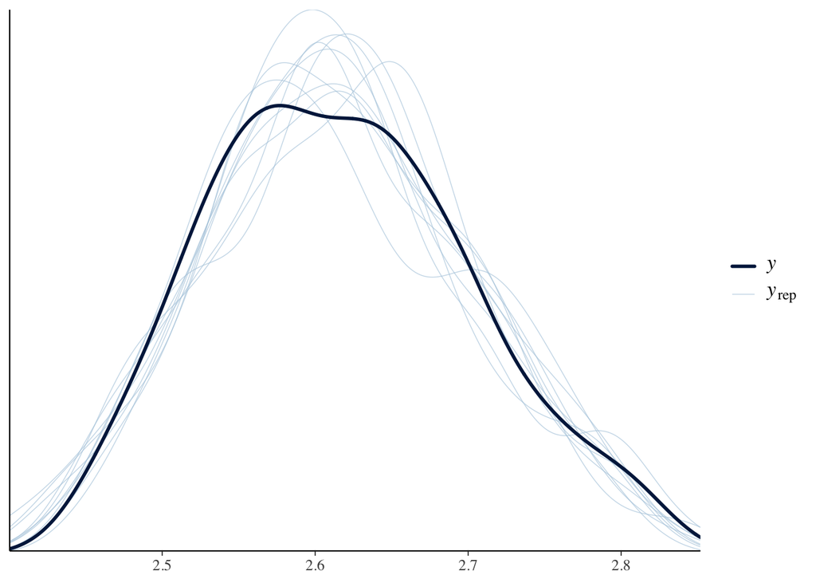

```r
pp_check(fit_8)
```

**Model summary**

```r
summary(fit_8)
```

```
 Family: gaussian
  Links: mu = identity
Formula: log10_ommatidia_area ~ log10_forewing_lenght * lifestyle * sex + (1 | gr(phylo, cov = A)) + (1 | species)
   Data: dat (Number of observations: 190)
  Draws: 4 chains, each with iter = 4000; warmup = 2000; thin = 1;
         total post-warmup draws = 8000

Multilevel Hyperparameters:
~phylo (Number of levels: 31)
              Estimate Est.Error l-95% CI u-95% CI Rhat Bulk_ESS Tail_ESS
sd(Intercept)     0.04      0.02     0.00     0.09 1.00     1398     2571

~species (Number of levels: 31)
              Estimate Est.Error l-95% CI u-95% CI Rhat Bulk_ESS Tail_ESS
sd(Intercept)     0.06      0.01     0.04     0.08 1.00     2796     4472

Regression Coefficients:
                                                 Estimate Est.Error l-95% CI
Intercept                                            2.38      0.14     2.11
log10_forewing_lenght                                0.18      0.11    -0.03
lifestylenocturnal                                  -0.08      0.16    -0.40
sexmale                                             -0.30      0.09    -0.48
log10_forewing_lenght:lifestylenocturnal             0.05      0.13    -0.19
log10_forewing_lenght:sexmale                        0.29      0.07     0.14
lifestylenocturnal:sexmale                           0.24      0.11     0.03
log10_forewing_lenght:lifestylenocturnal:sexmale    -0.21      0.09    -0.38
                                                 u-95% CI Rhat Bulk_ESS
Intercept                                            2.64 1.00     6446
log10_forewing_lenght                                0.39 1.00     6487
lifestylenocturnal                                   0.23 1.00     5223
sexmale                                             -0.12 1.00     6200
log10_forewing_lenght:lifestylenocturnal             0.30 1.00     5500
log10_forewing_lenght:sexmale                        0.43 1.00     6208
lifestylenocturnal:sexmale                           0.46 1.00     6078
log10_forewing_lenght:lifestylenocturnal:sexmale    -0.04 1.00     6070
                                                 Tail_ESS
Intercept                                            5733
log10_forewing_lenght                                6186
lifestylenocturnal                                   5381
sexmale                                              6171
log10_forewing_lenght:lifestylenocturnal             5394
log10_forewing_lenght:sexmale                        6076
lifestylenocturnal:sexmale                           5878
log10_forewing_lenght:lifestylenocturnal:sexmale     5948

Further Distributional Parameters:
      Estimate Est.Error l-95% CI u-95% CI Rhat Bulk_ESS Tail_ESS
sigma     0.03      0.00     0.03     0.03 1.00     8242     6104

Draws were sampled using sample(hmc). For each parameter, Bulk_ESS
and Tail_ESS are effective sample size measures, and Rhat is the potential
scale reduction factor on split chains (at convergence, Rhat = 1).
```

**Bayesian p-values**

```r
p_map(fit_8)
```

```
MAP-based p-value

Parameter                                        | p (MAP)
----------------------------------------------------------
(Intercept)                                      |  < .001
log10_forewing_lenght                            |  0.234
lifestylenocturnal                               |  0.877
sexmale                                          |  0.007
log10_forewing_lenght:lifestylenocturnal         |  0.899
log10_forewing_lenght:sexmale                    |  < .001
lifestylenocturnal:sexmale                       |  0.085
log10_forewing_lenght:lifestylenocturnal:sexmale |  0.055
```

**Bayesian R-square**

```r
bayes_R2(fit_8)
```

```
   Estimate Est.Error Q2.5 Q97.5
R2     0.89     0.008 0.87   0.9
```

**Phylogenetic signal**

```r
hyp <- paste(
  "sd_phylo__Intercept^2 /",
  "(sd_phylo__Intercept^2 + sd_species__Intercept^2 + sigma^2) = 0"
)
hypothesis(fit_8, hyp, class = NULL)
```

```
Hypothesis Tests for class :
                Hypothesis Estimate Est.Error CI.Lower CI.Upper Evid.Ratio
1 (sd_phylo__Interc... = 0     0.25       0.2        0     0.72       0.85
  Post.Prob Star
1      0.46    *
---
'CI': 90%-CI for one-sided and 95%-CI for two-sided hypotheses.
'*': For one-sided hypotheses, the posterior probability exceeds 95%;
for two-sided hypotheses, the value tested against lies outside the 95%-CI.
Posterior probabilities of point hypotheses assume equal prior probabilities.
```

# Figure 2

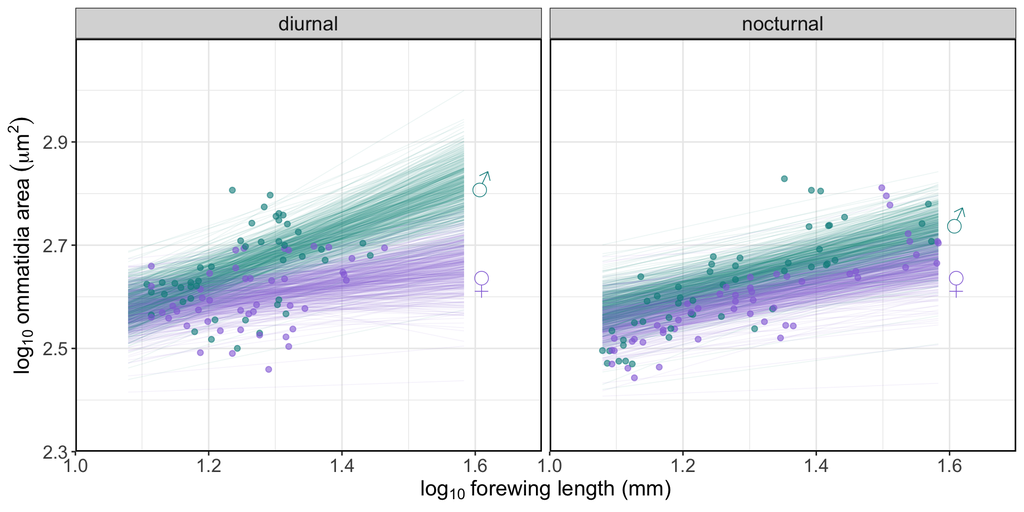

```r
# Create new dataset for predictions
newdata <- dat %>%
  data_grid(
    log10_forewing_lenght = seq(
      min(log10_forewing_lenght),
      max(log10_forewing_lenght),
      length.out = 100
    ),
    sex = c("female", "male"),
    lifestyle
  )

# Posterior expected values (population-level only)
predicted_draws <- add_epred_draws(
  fit_8,
  newdata = newdata,
  re_formula = NA,
  ndraws = 500
)

# Add Unicode symbols for sex
sex_symbols <- bind_rows(
  tibble(
    sex = c("female", "male"),
    symbol = c("\u2640", "\u2642"),
    x = c(1.61, 1.61),
    y = c(2.63, 2.82),
    size = c(7, 7),
    lifestyle = "diurnal"
  ),
  tibble(
    sex = c("female", "male"),
    symbol = c("\u2640", "\u2642"),
    x = c(1.61, 1.61),
    y = c(2.63, 2.75),
    size = c(7, 7),
    lifestyle = "nocturnal"
  )
)

Figure_2 <-
  ggplot(predicted_draws, aes(x = log10_forewing_lenght, y = .epred,
      group = interaction(sex, lifestyle, .draw),colour = sex)) +
  geom_line(alpha = 0.08,linewidth = 0.3) +
  geom_point(data = dat, aes(x = log10_forewing_lenght, y = log10_ommatidia_area,
      colour = sex), inherit.aes = FALSE, size = 1.6,
    alpha = 0.6) +
  geom_text(data = sex_symbols,aes(x = x, y = y, label = symbol, colour = sex),
            inherit.aes = FALSE, size = 7, fontface = "bold") +
  facet_wrap(~ lifestyle) +
  labs(
    x = expression(log[10]~"forewing length (mm)"),
    y = expression(log[10]~ommatidia~area~(mu*m^2)),
    colour = NULL) +
  scale_colour_manual(
    values = c(
      "female" = "#9370DB",
      "male"   = "#008B8B")) +
  scale_x_continuous(limits = c(1, 1.7), expand = c(0, 0)) +
  scale_y_continuous(limits = c(2.3, 3.1), expand = c(0, 0)) +
theme_bw() +
  theme(
    legend.position = "none",
    axis.text       = element_text(size = 13),
    axis.title      = element_text(size = 15),
    strip.text      = element_text(size = 14),
    panel.border    = element_rect(
      colour = "black",
      fill   = NA,
      linewidth = 1
    )
  )

Figure_2
```

```r
# Export Figure
ggsave("../outputs/Figure_2.png", Figure_2, width = 10, height = 5, units = "in")
```

# Does forewing length differ between sexes and lifestyles?

## Only sex

```r
fit_forewing_length_1 <- brm(
  log10_forewing_lenght ~  sex +
    (1 | gr(phylo, cov = A)) +
    (1 | species),
  data = dat,
  family = gaussian(),
  data2 = list(A = A),
  prior = c(
    prior(normal(0,10), "b"),
    prior(normal(0,50), "Intercept"),
    prior(student_t(3,0,20), "sd"),
    prior(student_t(3,0,20), "sigma")
  ),
  seed = 6955,
  sample_prior = TRUE,
  chains = 4,
  cores = 4,
  threads = threading(2),
  iter = 4000,
  warmup = 2000,
  control = list(max_treedepth = 15,
                 adapt_delta = 0.95),
  save_pars = save_pars(all = TRUE),
  silent = TRUE, refresh = 0
)
```

## Only lifestyle

```r
fit_forewing_length_2 <- brm(
  log10_forewing_lenght ~  lifestyle +
    (1 | gr(phylo, cov = A)) +
    (1 | species),
  data = dat,
  family = gaussian(),
  data2 = list(A = A),
  prior = c(
    prior(normal(0,10), "b"),
    prior(normal(0,50), "Intercept"),
    prior(student_t(3,0,20), "sd"),
    prior(student_t(3,0,20), "sigma")
  ),
  seed = 6955,
  sample_prior = TRUE,
  chains = 4,
  cores = 4,
  threads = threading(2),
  iter = 4000,
  warmup = 2000,
  control = list(max_treedepth = 15,
                 adapt_delta = 0.95),
  save_pars = save_pars(all = TRUE),
  silent = TRUE, refresh = 0
)
```

## Additive effects of sex and lifestyle

```r
fit_forewing_length_3 <- brm(
  log10_forewing_lenght ~  sex + lifestyle +
    (1 | gr(phylo, cov = A)) +
    (1 | species),
  data = dat,
  family = gaussian(),
  data2 = list(A = A),
  prior = c(
    prior(normal(0,10), "b"),
    prior(normal(0,50), "Intercept"),
    prior(student_t(3,0,20), "sd"),
    prior(student_t(3,0,20), "sigma")
  ),
  seed = 6955,
  sample_prior = TRUE,
  chains = 4,
  cores = 4,
  threads = threading(2),
  iter = 4000,
  warmup = 2000,
  control = list(max_treedepth = 15,
                 adapt_delta = 0.95),
  save_pars = save_pars(all = TRUE),
  silent = TRUE, refresh = 0
)
```

## Interactive effects of sex and life style

```r
fit_forewing_length_4 <- brm(
  log10_forewing_lenght ~  sex * lifestyle +
    (1 | gr(phylo, cov = A)) +
    (1 | species),
  data = dat,
  family = gaussian(),
  data2 = list(A = A),
  prior = c(
    prior(normal(0,10), "b"),
    prior(normal(0,50), "Intercept"),
    prior(student_t(3,0,20), "sd"),
    prior(student_t(3,0,20), "sigma")
  ),
  seed = 6955,
  sample_prior = TRUE,
  chains = 4,
  cores = 4,
  threads = threading(2),
  iter = 4000,
  warmup = 2000,
  control = list(max_treedepth = 15,
                 adapt_delta = 0.95),
  save_pars = save_pars(all = TRUE),
  silent = TRUE, refresh = 0
)
```

**Model check**

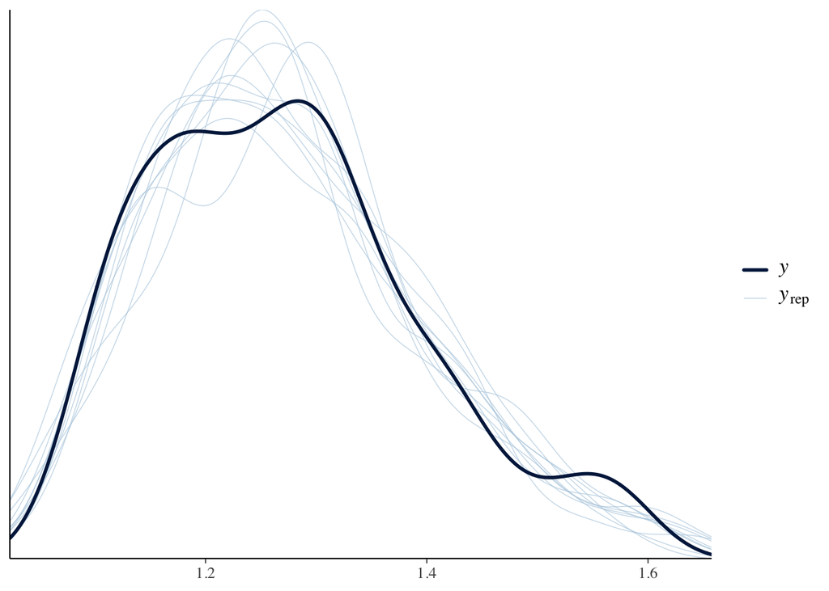

```r
pp_check(fit_forewing_length_4)
```

**Model summary**

```r
summary(fit_forewing_length_4)
```

```
 Family: gaussian
  Links: mu = identity
Formula: log10_forewing_lenght ~ sex * lifestyle + (1 | gr(phylo, cov = A)) + (1 | species)
   Data: dat (Number of observations: 190)
  Draws: 4 chains, each with iter = 4000; warmup = 2000; thin = 1;
         total post-warmup draws = 8000

Multilevel Hyperparameters:
~phylo (Number of levels: 31)
              Estimate Est.Error l-95% CI u-95% CI Rhat Bulk_ESS Tail_ESS
sd(Intercept)     0.04      0.04     0.00     0.15 1.00      911      988

~species (Number of levels: 31)
              Estimate Est.Error l-95% CI u-95% CI Rhat Bulk_ESS Tail_ESS
sd(Intercept)     0.12      0.02     0.09     0.16 1.00     2076     2495

Regression Coefficients:
                           Estimate Est.Error l-95% CI u-95% CI Rhat Bulk_ESS
Intercept                      1.26      0.04     1.17     1.34 1.00     1777
sexmale                       -0.01      0.01    -0.02     0.00 1.00     8223
lifestylenocturnal             0.05      0.05    -0.05     0.14 1.00     1384
sexmale:lifestylenocturnal    -0.02      0.01    -0.04    -0.00 1.00     8023
                           Tail_ESS
Intercept                      1949
sexmale                        5856
lifestylenocturnal             2210
sexmale:lifestylenocturnal     5537

Further Distributional Parameters:
      Estimate Est.Error l-95% CI u-95% CI Rhat Bulk_ESS Tail_ESS
sigma     0.03      0.00     0.03     0.04 1.00     9301     5813

Draws were sampled using sample(hmc). For each parameter, Bulk_ESS
and Tail_ESS are effective sample size measures, and Rhat is the potential
scale reduction factor on split chains (at convergence, Rhat = 1).
```

**Bayesian p-values**

```r
p_map(fit_forewing_length_4)
```

```
MAP-based p-value

Parameter                  | p (MAP)
------------------------------------
(Intercept)                |  < .001
sexmale                    |  0.401
lifestylenocturnal         |  0.562
sexmale:lifestylenocturnal |  0.106
```

**Bayesian R-square**

```r
bayes_R2(fit_forewing_length_4)
```

```
   Estimate Est.Error Q2.5 Q97.5
R2     0.92    0.0049 0.91  0.93
```

**Phylogenetic signal**

```r
hyp <- paste(
  "sd_phylo__Intercept^2 /",
  "(sd_phylo__Intercept^2 + sd_species__Intercept^2 + sigma^2) = 0"
)
hypothesis(fit_forewing_length_4, hyp, class = NULL)
```

```
Hypothesis Tests for class :
                Hypothesis Estimate Est.Error CI.Lower CI.Upper Evid.Ratio
1 (sd_phylo__Interc... = 0     0.13      0.17        0     0.61          3
  Post.Prob Star
1      0.75    *
---
'CI': 90%-CI for one-sided and 95%-CI for two-sided hypotheses.
'*': For one-sided hypotheses, the posterior probability exceeds 95%;
for two-sided hypotheses, the value tested against lies outside the 95%-CI.
Posterior probabilities of point hypotheses assume equal prior probabilities.
```

## Model comparison

[output not shown]

|  | Predictors | elpd_diff | se_diff | ratio |
| --- | --- | --- | --- | --- |
| model_4 | Sex × Lifestyle | 0 | 0 |  |
| model_3 | Lifestyle + Sex | -1.616709444393823 | 2.212460962285445 | 0.7307290261626954 |
| model_1 | Sex | -2.114264487562705 | 2.240040469131094 | 0.9438510226481858 |
| model_2 | Lifestyle | -10.34603315602211 | 4.905081021565623 | 2.109248167468561 |

# Does ommatidia area differ between sexes and lifestyles?

## Only sex

```r
fit_ommatidia_area_1 <- brm(
  log10_ommatidia_area ~  sex +
    (1 | gr(phylo, cov = A)) +
    (1 | species),
  data = dat,
  family = gaussian(),
  data2 = list(A = A),
  prior = c(
    prior(normal(0,10), "b"),
    prior(normal(0,50), "Intercept"),
    prior(student_t(3,0,20), "sd"),
    prior(student_t(3,0,20), "sigma")
  ),
  seed = 6955,
  sample_prior = TRUE,
  chains = 4,
  cores = 4,
  threads = threading(2),
  iter = 4000,
  warmup = 2000,
  control = list(max_treedepth = 15,
                 adapt_delta = 0.95),
  save_pars = save_pars(all = TRUE),
  silent = TRUE, refresh = 0
)
```

## Only lifestyle

```r
fit_ommatidia_area_2 <- brm(
  log10_ommatidia_area ~  lifestyle +
    (1 | gr(phylo, cov = A)) +
    (1 | species),
  data = dat,
  family = gaussian(),
  data2 = list(A = A),
  prior = c(
    prior(normal(0,10), "b"),
    prior(normal(0,50), "Intercept"),
    prior(student_t(3,0,20), "sd"),
    prior(student_t(3,0,20), "sigma")
  ),
  seed = 6955,
  sample_prior = TRUE,
  chains = 4,
  cores = 4,
  threads = threading(2),
  iter = 4000,
  warmup = 2000,
  control = list(max_treedepth = 15,
                 adapt_delta = 0.95),
  save_pars = save_pars(all = TRUE),
  silent = TRUE, refresh = 0
)
```

## Additive effects of sex and lifestyle

```r
fit_ommatidia_area_3 <- brm(
  log10_ommatidia_area ~  sex + lifestyle +
    (1 | gr(phylo, cov = A)) +
    (1 | species),
  data = dat,
  family = gaussian(),
  data2 = list(A = A),
  prior = c(
    prior(normal(0,10), "b"),
    prior(normal(0,50), "Intercept"),
    prior(student_t(3,0,20), "sd"),
    prior(student_t(3,0,20), "sigma")
  ),
  seed = 6955,
  sample_prior = TRUE,
  chains = 4,
  cores = 4,
  threads = threading(2),
  iter = 4000,
  warmup = 2000,
  control = list(max_treedepth = 15,
                 adapt_delta = 0.95),
  save_pars = save_pars(all = TRUE),
  silent = TRUE, refresh = 0
)
```

## Interactive effects of sex and life style

```r
fit_ommatidia_area_4 <- brm(
  log10_ommatidia_area ~  sex * lifestyle +
    (1 | gr(phylo, cov = A)) +
    (1 | species),
  data = dat,
  family = gaussian(),
  data2 = list(A = A),
  prior = c(
    prior(normal(0,10), "b"),
    prior(normal(0,50), "Intercept"),
    prior(student_t(3,0,20), "sd"),
    prior(student_t(3,0,20), "sigma")
  ),
  seed = 6955,
  sample_prior = TRUE,
  chains = 4,
  cores = 4,
  threads = threading(2),
  iter = 4000,
  warmup = 2000,
  control = list(max_treedepth = 15,
                 adapt_delta = 0.95),
  save_pars = save_pars(all = TRUE),
  silent = TRUE, refresh = 0
)
```

**Model check**

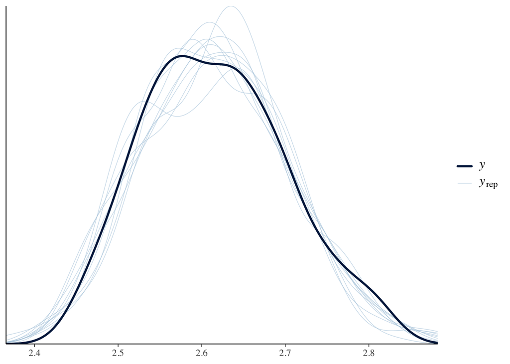

```r
pp_check(fit_ommatidia_area_4)
```

**Model summary**

```r
summary(fit_ommatidia_area_4)
```

```
 Family: gaussian
  Links: mu = identity
Formula: log10_ommatidia_area ~ sex * lifestyle + (1 | gr(phylo, cov = A)) + (1 | species)
   Data: dat (Number of observations: 190)
  Draws: 4 chains, each with iter = 4000; warmup = 2000; thin = 1;
         total post-warmup draws = 8000

Multilevel Hyperparameters:
~phylo (Number of levels: 31)
              Estimate Est.Error l-95% CI u-95% CI Rhat Bulk_ESS Tail_ESS
sd(Intercept)     0.04      0.03     0.00     0.11 1.00      938     1561

~species (Number of levels: 31)
              Estimate Est.Error l-95% CI u-95% CI Rhat Bulk_ESS Tail_ESS
sd(Intercept)     0.08      0.01     0.06     0.10 1.00     2539     3022

Regression Coefficients:
                           Estimate Est.Error l-95% CI u-95% CI Rhat Bulk_ESS
Intercept                      2.60      0.03     2.54     2.67 1.00     3321
sexmale                        0.06      0.01     0.04     0.07 1.00    10477
lifestylenocturnal            -0.00      0.03    -0.06     0.06 1.00     3018
sexmale:lifestylenocturnal    -0.02      0.01    -0.04    -0.00 1.00    10195
                           Tail_ESS
Intercept                      3466
sexmale                        6393
lifestylenocturnal             4445
sexmale:lifestylenocturnal     5972

Further Distributional Parameters:
      Estimate Est.Error l-95% CI u-95% CI Rhat Bulk_ESS Tail_ESS
sigma     0.03      0.00     0.03     0.03 1.00    11365     5284

Draws were sampled using sample(hmc). For each parameter, Bulk_ESS
and Tail_ESS are effective sample size measures, and Rhat is the potential
scale reduction factor on split chains (at convergence, Rhat = 1).
```

**Bayesian p-values**

```r
p_map(fit_ommatidia_area_4)
```

```
MAP-based p-value

Parameter                  | p (MAP)
------------------------------------
(Intercept)                |  < .001
sexmale                    |  < .001
lifestylenocturnal         |  0.990
sexmale:lifestylenocturnal |  0.048
```

**Bayesian R-square**

```r
bayes_R2(fit_ommatidia_area_4)
```

```
   Estimate Est.Error Q2.5 Q97.5
R2     0.87    0.0086 0.85  0.89
```

**Phylogenetic signal**

```r
hyp <- paste(
  "sd_phylo__Intercept^2 /",
  "(sd_phylo__Intercept^2 + sd_species__Intercept^2 + sigma^2) = 0"
)
hypothesis(fit_ommatidia_area_4, hyp, class = NULL)
```

```
Hypothesis Tests for class :
                Hypothesis Estimate Est.Error CI.Lower CI.Upper Evid.Ratio
1 (sd_phylo__Interc... = 0      0.2      0.19        0      0.7        1.3
  Post.Prob Star
1      0.57    *
---
'CI': 90%-CI for one-sided and 95%-CI for two-sided hypotheses.
'*': For one-sided hypotheses, the posterior probability exceeds 95%;
for two-sided hypotheses, the value tested against lies outside the 95%-CI.
Posterior probabilities of point hypotheses assume equal prior probabilities.
```

## Model comparison

|  | Predictors | elpd_diff | se_diff | ratio |
| --- | --- | --- | --- | --- |
| model_4 | Sex × Lifestyle | 0 | 0 |  |
| model_3 | Lifestyle + Sex | -2.25556756088857 | 2.646696567394804 | 0.8522199290524527 |
| model_1 | Sex | -2.662378108379151 | 2.711092352123723 | 0.9820315070763223 |
| model_2 | Lifestyle | -46.13565789691081 | 7.708500556486265 | 5.985036591596309 |

# Does forewing hindwing ratio differ between sexes and lifestyles?

## Only sex

```r
fit_forewing_hindwing_ratio_1 <- brm(
  forewing_hindwing_ratio ~  sex +
    (1 | gr(phylo, cov = A)) +
    (1 | species),
  data = dat,
  family = gaussian(),
  data2 = list(A = A),
  prior = c(
    prior(normal(0,10), "b"),
    prior(normal(0,50), "Intercept"),
    prior(student_t(3,0,20), "sd"),
    prior(student_t(3,0,20), "sigma")
  ),
  seed = 6955,
  sample_prior = TRUE,
  chains = 4,
  cores = 4,
  threads = threading(2),
  iter = 4000,
  warmup = 2000,
  control = list(max_treedepth = 15,
                 adapt_delta = 0.95),
  save_pars = save_pars(all = TRUE),
  silent = TRUE, refresh = 0
)
```

## Only lifestyle

```r
fit_forewing_hindwing_ratio_2 <- brm(
  forewing_hindwing_ratio ~  lifestyle +
    (1 | gr(phylo, cov = A)) +
    (1 | species),
  data = dat,
  family = gaussian(),
  data2 = list(A = A),
  prior = c(
    prior(normal(0,10), "b"),
    prior(normal(0,50), "Intercept"),
    prior(student_t(3,0,20), "sd"),
    prior(student_t(3,0,20), "sigma")
  ),
  seed = 6955,
  sample_prior = TRUE,
  chains = 4,
  cores = 4,
  threads = threading(2),
  iter = 4000,
  warmup = 2000,
  control = list(max_treedepth = 15,
                 adapt_delta = 0.95),
  save_pars = save_pars(all = TRUE),
  silent = TRUE, refresh = 0
)
```

## Additive effects of sex and lifestyle

```r
fit_forewing_hindwing_ratio_3 <- brm(
  forewing_hindwing_ratio ~  sex + lifestyle +
    (1 | gr(phylo, cov = A)) +
    (1 | species),
  data = dat,
  family = gaussian(),
  data2 = list(A = A),
  prior = c(
    prior(normal(0,10), "b"),
    prior(normal(0,50), "Intercept"),
    prior(student_t(3,0,20), "sd"),
    prior(student_t(3,0,20), "sigma")
  ),
  seed = 6955,
  sample_prior = TRUE,
  chains = 4,
  cores = 4,
  threads = threading(2),
  iter = 4000,
  warmup = 2000,
  control = list(max_treedepth = 15,
                 adapt_delta = 0.95),
  save_pars = save_pars(all = TRUE),
  silent = TRUE, refresh = 0
)
```

## Interactive effects of sex and life style

```r
fit_forewing_hindwing_ratio_4 <- brm(
  forewing_hindwing_ratio ~  sex * lifestyle +
    (1 | gr(phylo, cov = A)) +
    (1 | species),
  data = dat,
  family = gaussian(),
  data2 = list(A = A),
  prior = c(
    prior(normal(0,10), "b"),
    prior(normal(0,50), "Intercept"),
    prior(student_t(3,0,20), "sd"),
    prior(student_t(3,0,20), "sigma")
  ),
  seed = 6955,
  sample_prior = TRUE,
  chains = 4,
  cores = 4,
  threads = threading(2),
  iter = 4000,
  warmup = 2000,
  control = list(max_treedepth = 15,
                 adapt_delta = 0.95),
  save_pars = save_pars(all = TRUE),
  silent = TRUE, refresh = 0
)
```

**Model check**

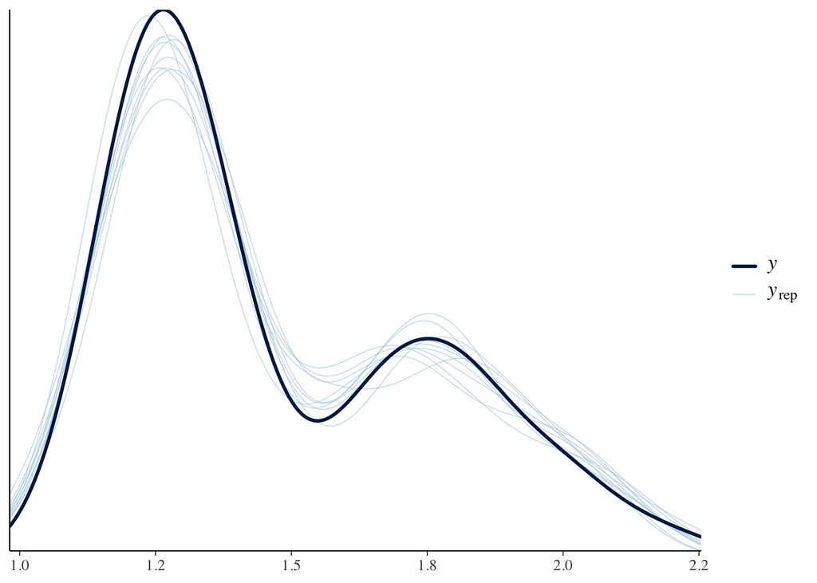

```r
pp_check(fit_forewing_hindwing_ratio_4)
```

**Model summary**

```r
summary(fit_forewing_hindwing_ratio_4)
```

```
 Family: gaussian
  Links: mu = identity
Formula: forewing_hindwing_ratio ~ sex * lifestyle + (1 | gr(phylo, cov = A)) + (1 | species)
   Data: dat (Number of observations: 186)
  Draws: 4 chains, each with iter = 4000; warmup = 2000; thin = 1;
         total post-warmup draws = 8000

Multilevel Hyperparameters:
~phylo (Number of levels: 31)
              Estimate Est.Error l-95% CI u-95% CI Rhat Bulk_ESS Tail_ESS
sd(Intercept)     0.13      0.11     0.01     0.42 1.01      740      850

~species (Number of levels: 31)
              Estimate Est.Error l-95% CI u-95% CI Rhat Bulk_ESS Tail_ESS
sd(Intercept)     0.27      0.04     0.20     0.37 1.00     1965     1773

Regression Coefficients:
                           Estimate Est.Error l-95% CI u-95% CI Rhat Bulk_ESS
Intercept                      1.59      0.11     1.36     1.82 1.00     2974
sexmale                       -0.01      0.01    -0.03     0.02 1.00     9028
lifestylenocturnal            -0.21      0.10    -0.41    -0.00 1.00     2320
sexmale:lifestylenocturnal     0.01      0.02    -0.02     0.05 1.00     9190
                           Tail_ESS
Intercept                      2935
sexmale                        6164
lifestylenocturnal             3765
sexmale:lifestylenocturnal     6166

Further Distributional Parameters:
      Estimate Est.Error l-95% CI u-95% CI Rhat Bulk_ESS Tail_ESS
sigma     0.06      0.00     0.06     0.07 1.00     9371     5585

Draws were sampled using sample(hmc). For each parameter, Bulk_ESS
and Tail_ESS are effective sample size measures, and Rhat is the potential
scale reduction factor on split chains (at convergence, Rhat = 1).
```

**Bayesian p-values**

```r
p_map(fit_forewing_hindwing_ratio_4)
```

```
MAP-based p-value

Parameter                  | p (MAP)
------------------------------------
(Intercept)                |  < .001
sexmale                    |  0.849
lifestylenocturnal         |  0.137
sexmale:lifestylenocturnal |  0.818
```

**Bayesian R-square**

```r
bayes_R2(fit_forewing_hindwing_ratio_4)
```

```
   Estimate Est.Error Q2.5 Q97.5
R2     0.95    0.0029 0.94  0.96
```

**Phylogenetic signal**

```r
hyp <- paste(
  "sd_phylo__Intercept^2 /",
  "(sd_phylo__Intercept^2 + sd_species__Intercept^2 + sigma^2) = 0"
)
hypothesis(fit_forewing_hindwing_ratio_4, hyp, class = NULL)
```

```
Hypothesis Tests for class :
                Hypothesis Estimate Est.Error CI.Lower CI.Upper Evid.Ratio
1 (sd_phylo__Interc... = 0     0.19      0.21        0     0.76        1.6
  Post.Prob Star
1      0.62    *
---
'CI': 90%-CI for one-sided and 95%-CI for two-sided hypotheses.
'*': For one-sided hypotheses, the posterior probability exceeds 95%;
for two-sided hypotheses, the value tested against lies outside the 95%-CI.
Posterior probabilities of point hypotheses assume equal prior probabilities.
```

## Model comparison

[output not shown]

|  | Predictors | elpd_diff | se_diff | ratio |
| --- | --- | --- | --- | --- |
| model_2 | Lifestyle | 0 | 0 |  |
| model_1 | Sex | -1.064006436968252 | 0.3013488439676607 | 3.530813070191953 |
| model_3 | Lifestyle + Sex | -1.304162119416902 | 0.2388184636749137 | 5.46089317948282 |
| model_4 | Sex × Lifestyle | -1.885913199983221 | 0.7261447709978052 | 2.597158686954067 |

# Figure 3

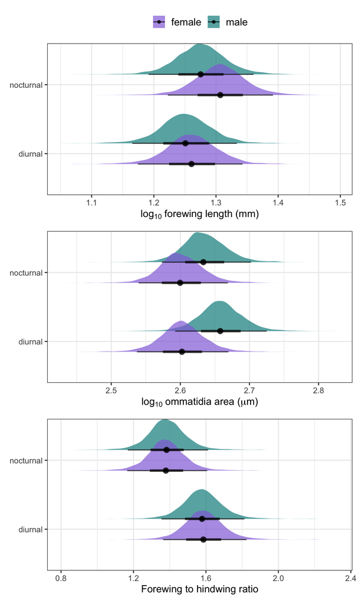

```r
# Define colors for each sex (these match the ones from Figure 2)

sex_colours <- c(
  "female" = "#9370DB",
  "male"   = "#008B8B"
)

# Function to obtain draws by each combination of sex and lifestyle

get_epred_interaction <- function(fit, response_label) {

  newdat <- expand.grid(
    sex       = c("female", "male"),
    lifestyle = c("diurnal", "nocturnal"),
    species   = NA,
    phylo     = NA
  )

  ep <- posterior_epred(
    fit,
    newdata    = newdat,
    re_formula = NA
  )

  ep_tidy <- as_tibble(ep) %>%
    mutate(draw = row_number()) %>%
    pivot_longer(-draw, names_to = "col", values_to = "value") %>%
    mutate(col = as.integer(sub("V", "", col))) %>%
    mutate(row_newdat = col) %>%
    left_join(
      newdat %>%
        mutate(row_newdat = row_number()),
      by = "row_newdat"
    ) %>%
    mutate(
      combo    = interaction(sex, lifestyle, sep = "_"),
      response = deparse(response_label)
    )

  ep_tidy
}

# Function to create a plot with sex and lifestyle interaction

make_plot_interaction <- function(fit, xlab) {

  ep_tidy <- get_epred_interaction(fit, response_label = xlab)

  ggplot(ep_tidy, aes(
    x    = value,
    y    = lifestyle,
    fill = sex
  )) +
    stat_halfeye(
      position       = position_dodge(width = 0.6),
      alpha          = 0.7,
      point_interval = "median_qi"
    ) +
    scale_fill_manual(values = sex_colours) +
    labs(x = xlab, y = "Lifestyle", fill = NULL) +
    theme_bw(base_size = 12) +
    theme(
      legend.position   = "top",
      legend.background = element_blank(),
      legend.key        = element_blank(),
      legend.text       = element_text(size = 12)
    )
}

# Make figure using function created above

Figure_3 <-
  make_plot_interaction(
    fit_forewing_length_4,
    expression(log[10] ~ "forewing length (mm)")
  ) /
  make_plot_interaction(
    fit_ommatidia_area_4,
    expression(log[10] ~ "ommatidia area (" * mu * "m)")
  ) /
  make_plot_interaction(
    fit_forewing_hindwing_ratio_4,
    "Forewing to hindwing ratio"
  ) +
  plot_layout(
    guides  = "collect",
    heights = c(1, 1, 1)
  ) &
  theme(
    legend.position = "top",
    axis.title.y    = element_blank()
  )

Figure_3
```

```r
ggsave(
  "../Outputs/Figure_3.pdf",
  Figure_3,
  width  = 6,
  height = 10,
  units  = "in"
)
```

# Session information

**R version 4.5.2 (2025-10-31)**

**Platform:** aarch64-apple-darwin20

**attached base packages:** *stats*, *graphics*, *grDevices*, *utils*, *datasets*, *methods* and *base*

**other attached packages:** *ggnewscale(v.0.5.2)*, *ggridges(v.0.5.7)*, *patchwork(v.1.3.2)*, *emmeans(v.2.0.2)*, *DT(v.0.34.0)*, *modelr(v.0.1.11)*, *viridis(v.0.6.5)*, *viridisLite(v.0.4.3)*, *posterior(v.1.7.0)*, *lubridate(v.1.9.5)*, *forcats(v.1.0.1)*, *readr(v.2.2.0)*, *tidyverse(v.2.0.0)*, *furrr(v.0.3.1)*, *future(v.1.69.0)*, *cmdstanr(v.0.9.0.9000)*, *purrr(v.1.2.2)*, *loo(v.2.9.0)*, *bayestestR(v.0.17.0)*, *tidybayes(v.3.0.7)*, *bayesplot(v.1.15.0.9000)*, *dplyr(v.1.2.1)*, *brms(v.2.23.0)*, *Rcpp(v.1.1.1-1.1)*, *tidyr(v.1.3.2)*, *stringr(v.1.6.0)*, *details(v.0.4.0)*, *ggthemes(v.5.2.0)*, *tibble(v.3.3.1)*, *ggtree(v.4.0.5)*, *cowplot(v.1.2.0)*, *ggpubr(v.0.6.3)*, *ggplot2(v.4.0.3)*, *kableExtra(v.1.4.0)*, *readxl(v.1.4.5)*, *phytools(v.2.5-2)*, *maps(v.3.4.3)*, *ape(v.5.8-1)* and *knitr(v.1.51)*

**loaded via a namespace (and not attached):** *svUnit(v.1.0.8)*, *splines(v.4.5.2)*, *ggplotify(v.0.1.3)*, *cellranger(v.1.1.0)*, *datawizard(v.1.3.0)*, *lifecycle(v.1.0.5)*, *rstatix(v.0.7.3)*, *StanHeaders(v.2.32.10)*, *doParallel(v.1.0.17)*, *globals(v.0.19.0)*, *processx(v.3.9.0)*, *lattice(v.0.22-9)*, *MASS(v.7.3-65)*, *crosstalk(v.1.2.2)*, *insight(v.1.4.6)*, *ggdist(v.3.3.3)*, *backports(v.1.5.1)*, *magrittr(v.2.0.5)*, *sass(v.0.4.10)*, *rmarkdown(v.2.31)*, *jquerylib(v.0.1.4)*, *yaml(v.2.3.12)*, *otel(v.0.2.0)*, *pkgbuild(v.1.4.8)*, *RColorBrewer(v.1.1-3)*, *multcomp(v.1.4-29)*, *abind(v.1.4-8)*, *expm(v.1.0-0)*, *quadprog(v.1.5-8)*, *yulab.utils(v.0.2.4)*, *TH.data(v.1.1-5)*, *tensorA(v.0.36.2.1)*, *rappdirs(v.0.3.4)*, *sandwich(v.3.1-1)*, *gdtools(v.0.5.0)*, *inline(v.0.3.21)*, *listenv(v.0.10.0)*, *tidytree(v.0.4.7)*, *bridgesampling(v.1.2-1)*, *parallelly(v.1.46.1)*, *svglite(v.2.2.2)*, *codetools(v.0.2-20)*, *xml2(v.1.5.2)*, *tidyselect(v.1.2.1)*, *aplot(v.0.2.9)*, *farver(v.2.1.2)*, *stats4(v.4.5.2)*, *matrixStats(v.1.5.0)*, *jsonlite(v.2.0.0)*, *Formula(v.1.2-5)*, *survival(v.3.8-6)*, *iterators(v.1.0.14)*, *systemfonts(v.1.3.2)*, *foreach(v.1.5.2)*, *tools(v.4.5.2)*, *treeio(v.1.34.0)*, *ragg(v.1.5.1)*, *glue(v.1.8.1)*, *mnormt(v.2.1.2)*, *gridExtra(v.2.3)*, *xfun(v.0.58)*, *distributional(v.0.7.0)*, *withr(v.3.0.2)*, *numDeriv(v.2016.8-1.1)*, *combinat(v.0.0-8)*, *fastmap(v.1.2.0)*, *callr(v.3.7.6)*, *digest(v.0.6.39)*, *timechange(v.0.4.0)*, *R6(v.2.6.1)*, *gridGraphics(v.0.5-1)*, *estimability(v.1.5.1)*, *colorspace(v.2.1-2)*, *textshaping(v.1.0.5)*, *generics(v.0.1.4)*, *fontLiberation(v.0.1.0)*, *data.table(v.1.18.2.1)*, *clusterGeneration(v.1.3.8)*, *httr(v.1.4.8)*, *htmlwidgets(v.1.6.4)*, *scatterplot3d(v.0.3-45)*, *pkgconfig(v.2.0.3)*, *gtable(v.0.3.6)*, *S7(v.0.2.2)*, *htmltools(v.0.5.9)*, *fontBitstreamVera(v.0.1.1)*, *carData(v.3.0-6)*, *scales(v.1.4.0)*, *png(v.0.1-9)*, *ggfun(v.0.2.0)*, *rstudioapi(v.0.18.0)*, *reshape2(v.1.4.5)*, *tzdb(v.0.5.0)*, *curl(v.7.1.0)*, *coda(v.0.19-4.1)*, *checkmate(v.2.3.4)*, *nlme(v.3.1-168)*, *cachem(v.1.1.0)*, *zoo(v.1.8-15)*, *DEoptim(v.2.2-8)*, *parallel(v.4.5.2)*, *desc(v.1.4.3)*, *pillar(v.1.11.1)*, *grid(v.4.5.2)*, *vctrs(v.0.7.3)*, *car(v.3.1-5)*, *arrayhelpers(v.1.1-0)*, *xtable(v.1.8-8)*, *evaluate(v.1.0.5)*, *mvtnorm(v.1.3-6)*, *cli(v.3.6.6)*, *compiler(v.4.5.2)*, *rlang(v.1.2.0)*, *rstantools(v.2.6.0)*, *ggsignif(v.0.6.4)*, *labeling(v.0.4.3)*, *ps(v.1.9.3)*, *plyr(v.1.8.9)*, *fs(v.2.1.0)*, *pander(v.0.6.6)*, *rstan(v.2.32.7)*, *ggiraph(v.0.9.6)*, *stringi(v.1.8.7)*, *QuickJSR(v.1.9.0)*, *lazyeval(v.0.2.3)*, *optimParallel(v.1.0-2)*, *V8(v.8.0.1)*, *Brobdingnag(v.1.2-9)*, *fontquiver(v.0.2.1)*, *Matrix(v.1.7-4)*, *hms(v.1.1.4)*, *clipr(v.0.8.0)*, *igraph(v.2.3.1)*, *broom(v.1.0.12)*, *bslib(v.0.11.0)*, *RcppParallel(v.5.1.11-2)*, *phangorn(v.2.12.1)* and *fastmatch(v.1.1-8)*